# RFC

Kayla Williams

11/19/2021

```r
library(tigris)
library(tidyverse)
library(tidycensus)
library(sf)
library(censusapi)
library(leaflet)
library(StatMatch)
library(survey)
library(dplyr)
library(mapview)
library(ggplot2)
library(lubridate)
Sys.setenv(CENSUS_KEY="c8aa67e4086b4b5ce3a8717f59faa9a28f611dab")
```

1. TRENDS IN MUTUAL AID

New York has seen an increase in interest around Mutual Aid in comparison to prepandemic levels, interest being measured through Google searches of the term.

```r
mutual_aid_searches_5yr = read_csv("mutualaid_searches_5yr.csv")
mutual_aid_searches_5yr = mutual_aid_searches_5yr[3:nrow(mutual_aid_searches_5yr), ]
```

```r
searches_5yr = mutual_aid_searches_5yr %>%
  rename("Week" = "Category: All categories", "Count" = "X2") %>%
  mutate(
    Week = as.Date(Week, "%Y-%m-%d"),
    Count = as.numeric(Count),
    Covid = ifelse(Week > "2020-03-01", 1, 0),
    Season = ifelse(month(Week) %in% c(12, 1, 2), 1,
                    ifelse(month(Week) %in% c(3, 4, 5), 2,
                           ifelse(month(Week) %in% c(6, 7, 8), 3, 4))),
    Sustained = ifelse(year(Week) == 2021, 1, 0))
```

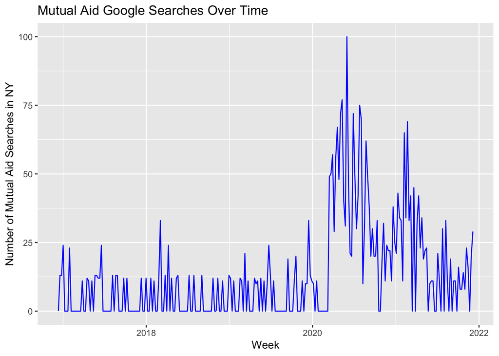

```r
searches_5yr %>%
  ggplot(
      aes(x = Week,
        y = Count
      )
    ) +
    geom_line(color = "blue") +
    labs(
      x = "Week",
      y = "Number of Mutual Aid Searches in NY",
      title = "Mutual Aid Google Searches Over Time "
    ) +
  geom_line(y= as.Date("2020-03-01"))
```

```r
summary(lm(Count~Covid + Season, searches_5yr))
```

```
##
## Call:
## lm(formula = Count ~ Covid + Season, data = searches_5yr)
##
## Residuals:
##     Min      1Q  Median      3Q     Max
## -29.873  -7.784  -0.397   5.780  70.127
##
## Coefficients:
##             Estimate Std. Error t value Pr(>|t|)
## (Intercept)  12.0422     2.1538   5.591 5.74e-08 ***
## Covid        23.6533     1.8248  12.962  < 2e-16 ***
## Season       -2.9112     0.7809  -3.728 0.000237 ***
## ---
## Signif. codes:  0 '***' 0.001 '**' 0.01 '*' 0.05 '.' 0.1 ' ' 1
##
## Residual standard error: 13.96 on 258 degrees of freedom
## Multiple R-squared:  0.4003, Adjusted R-squared:  0.3957
## F-statistic: 86.12 on 2 and 258 DF,  p-value: < 2.2e-16
```

The impact is less strong in 2021, the relative increase from pre 2020 amounting to roughly 8 in comparison to 24 for post 3/1/2020. However, this is still a sustained impact, even if reduced, and suggests that RFC started right on time -- at a point when there was a lot of interest around what we do. The reduced impact could signal, not so much a decrease in interest, but that people already know what it means now -- they aren't doing initial searches anymore.

```r
summary(lm(Count~ Season + Sustained, searches_5yr))
```

```
##
## Call:
## lm(formula = Count ~ Season + Sustained, data = searches_5yr)
##
## Residuals:
##     Min      1Q  Median      3Q     Max
## -20.312 -10.784  -5.912   2.915  87.516
##
## Coefficients:
##             Estimate Std. Error t value Pr(>|t|)
## (Intercept)   15.884      2.716   5.849  1.5e-08 ***
## Season        -1.700      0.981  -1.733  0.08433 .
## Sustained      7.828      2.804   2.791  0.00564 **
## ---
## Signif. codes:  0 '***' 0.001 '**' 0.01 '*' 0.05 '.' 0.1 ' ' 1
##
## Residual standard error: 17.68 on 258 degrees of freedom
## Multiple R-squared:  0.03882,    Adjusted R-squared:  0.03137
## F-statistic:  5.21 on 2 and 258 DF,  p-value: 0.006051
```

2. MUTUAL AID IN BROOKLYN
1. How prominent are the populations we care about (poverty, non citizens, children in the household and lack of internet access)

```r
acs_vars_2019_5yr =
  listCensusMetadata(
    name = "2019/acs/acs5",
    type = "variables"
  )
```

```r
bk_tracts = tracts("New York", "Kings County") %>%
  mutate(GEOID = as.numeric(GEOID))
brooklyn_vars_data =
  getCensus(
  name = "acs/acs5",
  vintage = 2019,
  region = "tract:*",
  regionin = "state:36+county:047",
  vars = c( "B01001_001E", "B17015_002E", "B05001_006E", "B11005_002E", "B28002_013E")
  ) %>%
  mutate(
    tract = paste0(state, county, tract),
    tract = as.numeric(tract)
  ) %>%

  rename("population" =  B01001_001E) %>%
  rename("poverty" = B17015_002E) %>%
  rename("noncitizen" = B05001_006E) %>%
  rename("children" = B11005_002E) %>%
  rename("nointernet" = B28002_013E) %>%
  mutate(povertyrate = poverty/population *100) %>%
  mutate(noncitizenrate = noncitizen/population *100) %>%
  mutate(childrenrate = children/population *100) %>%
  mutate(nointernetrate = nointernet/population*100) %>%
  select(!c(state, county)) %>%
  mutate(tract = as.numeric(tract)) %>%
  filter(
    !is.na(povertyrate),
    !is.na(noncitizenrate),
    !is.na(childrenrate),
    !is.na(nointernetrate)
  )
```

```r
brooklyn_outcomes = bk_tracts %>%
  select(GEOID, geometry) %>%
  left_join(brooklyn_vars_data, by = c("GEOID" = "tract")) %>% drop_na()
```

```r
outcome_table = pivot_longer(brooklyn_outcomes,!c(geometry, GEOID), names_to = "variable", values_to = "numbers")
```

```r
pov_pal = colorNumeric(
  palette = "Blues",
  domain =
    brooklyn_outcomes$poverty
)


povertymap =
  leaflet() %>%
  addTiles() %>%
  addPolygons(
    data = brooklyn_outcomes,
    fillColor = ~pov_pal(poverty),
    color = "white",
    opacity = 0.5,
    fillOpacity = .6,
    weight = 1,
    label = ~paste0(
      round(poverty),
      " households below the poverty line in", GEOID
    ),
    highlightOptions = highlightOptions(
      weight = 2,
      opacity = 1
    )
  ) %>%
  addLegend(
    data = brooklyn_outcomes,
    pal = pov_pal,
    values = ~poverty,
    title = "Households Below the Poverty Threshold"
  )

povertymap
```

[interactive chart not shown]

```r
citiz_pal= colorNumeric(
  palette = "Greens",
  domain = brooklyn_outcomes$noncitizen
)
noncitizenmap = leaflet() %>%
  addTiles() %>%
  addPolygons(
    data = brooklyn_outcomes,
    fillColor = ~citiz_pal(noncitizen),
    color = "white",
    opacity = 0.5,
    fillOpacity = .5,
    weight = 1,
    label = ~paste0(
      round(noncitizen),
      " households with non citizens"
    ),
    highlightOptions = highlightOptions(
      weight = 2,
      opacity = 1
    )
  ) %>%
  addLegend(
    data = brooklyn_outcomes,
    pal = citiz_pal,
    values = ~noncitizen,
    title = "Households with Non US Citizens"
  )
noncitizenmap
```

[interactive chart not shown]

```r
child_pal = colorNumeric(
  palette = "Reds",
  domain = brooklyn_outcomes$children
)

childrenmap = leaflet() %>%
  addTiles() %>%
  addPolygons(
    data = brooklyn_outcomes,
    fillColor = ~child_pal(children),
    color = "white",
    opacity = 0.5,
    fillOpacity = .5,
    weight = 1,
    label = ~paste0(
      round(children),
      " households with children under 18 present"
    ),
    highlightOptions = highlightOptions(
      weight = 2,
      opacity = 1
    )
  ) %>%
  addLegend(
    data = brooklyn_outcomes,
    pal = child_pal,
    values = ~children,
    title = "Households with Children Under 18 Present"
  )
childrenmap
```

[interactive chart not shown]

```r
wifi_pal = colorNumeric(
  palette = "Oranges",
  domain = brooklyn_outcomes$nointernet
)

nowifimap = leaflet() %>%
  addTiles() %>%
  addPolygons(
    data = brooklyn_outcomes,
    fillColor = ~wifi_pal(nointernet),
    color = "white",
    opacity = 0.5,
    fillOpacity = .5,
    weight = 1,
    label = ~paste0(
      round(nointernet),
      " households without internet access"
    ),
    highlightOptions = highlightOptions(
      weight = 2,
      opacity = 1
    )
  ) %>%
  addLegend(
    data = brooklyn_outcomes,
    pal = wifi_pal,
    values = ~nointernet,
    title = "Households without Internet Access"
  )
nowifimap
```

[interactive chart not shown]

The data for non citizens shows the largest clusters in the Sunset Park area, which is about 1/3 Hispanic, 1/3 Asian and then about 1/5 White and the rest split up between other races. This shocked me the most because the prototype in my head of noncitizens is especially those from the Caribbean and African countries, like I'd see in my owwn neighborhood, Flatbush, but this makes sense. There are a few other dense chunks of non citizens, in Flatbush, more like I guessed there'd be, though less prevalent as I'd suspect. While it is difficult to know how much of that is due to comfortability answering this question on the Census, this information was revelang, especially in bringing my attention to an area I hadn't previously thought of as a target.

The poverty map, interestingly highlights a similar density of clusters in the Sunset Park area but also draws the eye to the edges of the city, especially to the East, toward East New York and higher up toward Bushwick, somewhat infamous areas for being "tougher" or more prone to issues of poverty and violence.

Households without internet access also follow similar trendss, with clusters in the aforementioned aread especially, but surprsingly more spread throughout.

Finally the children present map, as expected is spread throughout Brooklyn,

I was shocked that the no wifi and children present maps didn't look more similar.

2. What's the relationship between these variables?

```r
summary(lm(povertyrate ~ noncitizenrate + childrenrate + nointernetrate, brooklyn_outcomes))
```

```
##
## Call:
## lm(formula = povertyrate ~ noncitizenrate + childrenrate + nointernetrate,
##     data = brooklyn_outcomes)
##
## Residuals:
##     Min      1Q  Median      3Q     Max
## -5.9202 -1.2379 -0.1626  0.9799  9.1003
##
## Coefficients:
##                 Estimate Std. Error t value Pr(>|t|)
## (Intercept)    -3.508188   0.354169  -9.905  < 2e-16 ***
## noncitizenrate  0.045256   0.008131   5.566 3.64e-08 ***
## childrenrate    0.359794   0.026982  13.334  < 2e-16 ***
## nointernetrate  0.361271   0.018500  19.529  < 2e-16 ***
## ---
## Signif. codes:  0 '***' 0.001 '**' 0.01 '*' 0.05 '.' 0.1 ' ' 1
##
## Residual standard error: 1.865 on 748 degrees of freedom
## Multiple R-squared:  0.4312, Adjusted R-squared:  0.429
## F-statistic: 189.1 on 3 and 748 DF,  p-value: < 2.2e-16
```

The children and no internet rates have the strongest impacts on poverty rates of the variables, a percent increase in each corresponding to an increase in the the poverty rate by about .4%. I'd argue that these are high enough for us to also prioritize internet access in our work and to continue to look at children as an entry point into families..

I think I was most surprised to ssee that my neighborhood itself wasn't at heavily saturated with these outcomes as I assumed, highlighting both that my family's experiences aren't the most saturated and that our work should have emphasized efforts in other parts of Brooklyn.

3. How do we go about deciding on our target audiences/ focal points?

Having spot an area of interest, Breukelen Houses -- a housing complex with high rates for poverty, children present and lack of internet access, what are some tracts like this one? Are these other good target areas?

```r
obs_matrix =
  brooklyn_outcomes %>%
  select(povertyrate,
         noncitizenrate,
         nointernetrate,
         childrenrate)  %>%
  st_drop_geometry()
```

```r
dist_matrix = mahalanobis.dist(obs_matrix)

rownames(dist_matrix) = brooklyn_outcomes$GEOID
colnames(dist_matrix) = brooklyn_outcomes$GEOID
```

```r
match_tract = dist_matrix["36047098200", ] %>%
  as.data.frame() %>%
  rownames_to_column() %>%
  rename(
    GEOID = rowname,
    match = "."
  ) %>%
  arrange(match) %>%
  .[1:21, ] %>%
  mutate(GEOID = as.numeric(GEOID)) %>%
  left_join(bk_tracts %>% select(GEOID = GEOID)) %>%
  st_as_sf()
```

How will these matches compare to top tracts according to my index?

This index, somewhat similarly to the logic in the Calenviroscreen index, averages poverty and no internet rates, as a measure of general inaccess, and multiplies this by the average of children and non citizen rates, as these charactersistics are used as measures added vulnerability, which would exacerbate already present issues of inaccess.

```r
brooklyn_outcomes = brooklyn_outcomes %>%
  mutate(index = (povertyrate + nointernetrate)/2  * (childrenrate + noncitizenrate)/2 )


top_tracts = brooklyn_outcomes %>%
  arrange(desc(index)) %>%
  .[1:30, ]
```

```r
nycha_data = read_csv("NYCHAdevelopments.csv") %>%
  filter(BOROUGH == "BROOKLYN") %>%
  rename("geometry" = the_geom)

nychouses = sf::st_as_sf(nycha_data, wkt = "geometry")
```

```r
leaflet() %>%
  addProviderTiles(providers$CartoDB.Positron) %>%
  addPolygons(
    data = match_tract[1, ],
    color = "green"
  ) %>%
  addPolygons(
    data = match_tract[-1, ],
    color = "yellow"
  ) %>%
  addPolygons(
    data = top_tracts,
    color = "red"
  ) %>%
  addMarkers(data = nychouses$geometry %>%
               st_centroid)
```

[interactive chart not shown]

Here we see housing projects as blue markers, tracts that are most similar to the Breukelen Houses tract in yellow and tracts that are most vulnerable by my index in red. The three have a lot of overlap (as seen with the orange tracts) and are clustered in the same areas, especially East New York, Bushwich and Coney Island. RFC has previously focused on schools as an entry point into families, but maybe we can look to housing projects, either the schools near them or the complexes themselves as they house many of the most vulnerable populations -- I know of another organization that works directly out of the complexes that we could learn from.

Interestingly, though, there are regions of red and yellow in Sunset Park, as the individual variable maps showed high volumes of poverty, no internet and non citizens -- however, there aren't housing projects there. In terms of our programming, this would create questions of whether we'd want to simulanesoulsy focus efforts in this area or focus on the housing projects route first and then turn to them.

Compare PUMS findings to Census Findings

```r
pums_2019_1yr <- getCensus(
  name = "acs/acs1/pums",
  vintage = 2019,
  region = "public use microdata area:*",
  regionin = "state:36",
  vars = c(
    "SERIALNO",
    "SPORDER",
    "PWGTP",
    "WGTP",
    "POVPIP",
    "ACCESS",
    "HUPAC",
    "CIT"
  )
)

saveRDS(pums_2019_1yr, "pums_2019_1yr.rds")
pums2019 = readRDS("pums_2019_1yr.rds")
```

```r
ny_pumas =
  pumas("NY", cb = T, progress_bar = F)

bkcounty =
  counties("NY", cb = T, progress_bar = F) %>%
  filter(NAME == "Kings")

bk_pumas =
  ny_pumas %>%
  st_centroid() %>%
  .[bkcounty, ] %>%
  st_drop_geometry() %>%
  left_join(ny_pumas %>% select(GEOID10)) %>%
  st_as_sf()

bk_pums <-
  pums_2019_1yr %>%
  mutate(
    PUMA = str_pad(public_use_microdata_area,5,"left","0")
  ) %>%
  filter(PUMA %in% bk_pumas$PUMACE10)

bk_microdata =
  bk_pums %>%
  filter(SPORDER == 1) %>%
  mutate(
    WGTP = as.numeric(WGTP),
    POVPIP = as.numeric(POVPIP),
    ACCESS = as.numeric(ACCESS),
    HUPAC = as.numeric(HUPAC),
    CIT = as.numeric(CIT),
    poverty = ifelse(POVPIP <= 100, 1, 0),
    children = ifelse(HUPAC %in% c(1,2,3), 1, 0),
    nointernet = ifelse(ACCESS == 3, 1, 0),
    noncitizen = ifelse(CIT == 5, 1, 0)) %>%
  rowwise() %>%
    mutate(vulnerability = (poverty +  nointernet) * (1 + children + noncitizen),
           weightedvul = vulnerability*WGTP,
           maxvul = 6*WGTP) %>%
  group_by(PUMA) %>%
  summarize(
    ratevul = sum(weightedvul)/ sum(maxvul) ) %>%
  left_join(
    bk_pumas %>%
      select(PUMACE10),
    by = c("PUMA" = "PUMACE10")
  ) %>%
  st_as_sf()

pums_pal <- colorNumeric(
  palette = "Oranges",
  domain = bk_microdata$ratevul
)

vulnerablemap = leaflet() %>%
  addTiles() %>%
  addPolygons(
    data = bk_microdata,
    fillColor = ~pums_pal(ratevul),
    color = "white",
    opacity = 0.5,
    fillOpacity = 0.5,
    weight = 1,
    label = ~paste(
      (ratevul),
      "vulnerabilities across Brooklyn"
    ),
    highlightOptions = highlightOptions(
      weight = 2,
      opacity = 1
    )
  ) %>%
  addLegend(
    data = bk_microdata,
    pal = pums_pal,
    values = ~ratevul,
    title = "rate of vulnerabilities"
  ) %>%
  addMarkers(data = nychouses$geometry %>%
               st_centroid)
```

The findings are stull pretty supportive of earlier findings, though, about the areas we should focus on and the opportunity to use housing projects as entry points.